# Παλινδρόμηση με πολυωνυμικό μοντέλο 2ης τάξης (Quadratic)

Το παρακάτω αρχείο περιγράφει την σχέση ανάμεσα στις ώρες εργασίας ανά εβδομάδα και στον βαθμό ευτυχίας (με κλίμακα 0-100).

```r
data <- data.frame(hours=c(6, 9, 12, 14, 30, 35, 40, 47, 51, 55, 60),
                   happiness=c(14, 28, 50, 70, 89, 94, 90, 75, 59, 44, 27))
data
```

| hours | happiness |
| --- | --- |
| 6 | 14 |
| 9 | 28 |
| 12 | 50 |
| 14 | 70 |
| 30 | 89 |
| 35 | 94 |
| 40 | 90 |
| 47 | 75 |
| 51 | 59 |
| 55 | 44 |

[output cut: 1 more lines]

Αν οπτικοποιήσουμε τα δεδομένα σε ένα διάγραμμα διασπορά (scatterplot) άμεσα γίνεται αντιληπτό ότι η σχέση που συνδέει τις δύο μεταβλητές είναι μη γραμμική.

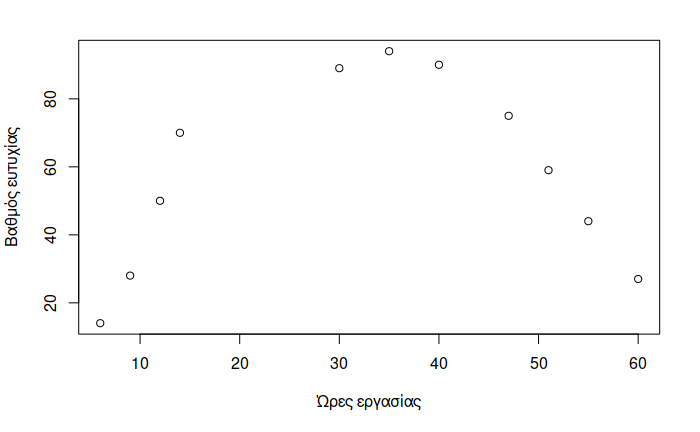

```r
plot(data$hours, data$happiness, xlab="Ώρες εργασίας", ylab="Βαθμός ευτυχίας")
```

Αυτό άλλωστε επιβεβαιώνεται και από την προσπάθεια προσαρμογής ευθείας ελαχίστων τετραγώνων.

```r
linearModel <- lm(happiness ~ hours, data=data)
summary(linearModel)
```

```
Call:
lm(formula = happiness ~ hours, data = data)

Residuals:
   Min     1Q Median     3Q    Max
-39.34 -21.99  -2.03  23.50  35.11

Coefficients:
            Estimate Std. Error t value Pr(>|t|)
(Intercept)  48.4531    17.3288   2.796   0.0208 *
hours         0.2981     0.4599   0.648   0.5331
---
Signif. codes:  0 ‘***’ 0.001 ‘**’ 0.01 ‘*’ 0.05 ‘.’ 0.1 ‘ ’ 1

Residual standard error: 28.72 on 9 degrees of freedom
Multiple R-squared:  0.0446,    Adjusted R-squared:  -0.06156
F-statistic: 0.4201 on 1 and 9 DF,  p-value: 0.5331
```

Όπως φαίνεται από τον συντελεστή προσδιορισμο μόνο το 4,46% της μεταβλητότητας του βαθμού ευτυχίας ερμηνεύεται από την μεταβολή των ωρών εργασίας.

Ας δοκιμάσουμε να προσαρμόσουμε μια γραμμή με βάση ένα πολυώνυμο β’ βαθμου δηλ. της μορφή y=a+bx+cx^2 μιας και από την καμπύλη φαίνεται η σχέση να περιγράφεται από μια παραβολή.

```r
data$hours2 <- data$hours^2
quadraticModel <- lm(happiness ~ hours + hours2, data=data)
summary(quadraticModel)
```

```
Call:
lm(formula = happiness ~ hours + hours2, data = data)

Residuals:
    Min      1Q  Median      3Q     Max
-6.2484 -3.7429 -0.1812  1.1464 13.6678

Coefficients:
             Estimate Std. Error t value Pr(>|t|)
(Intercept) -18.25364    6.18507  -2.951   0.0184 *
hours         6.74436    0.48551  13.891 6.98e-07 ***
hours2       -0.10120    0.00746 -13.565 8.38e-07 ***
---
Signif. codes:  0 ‘***’ 0.001 ‘**’ 0.01 ‘*’ 0.05 ‘.’ 0.1 ‘ ’ 1

Residual standard error: 6.218 on 8 degrees of freedom
Multiple R-squared:  0.9602,    Adjusted R-squared:  0.9502
F-statistic: 96.49 on 2 and 8 DF,  p-value: 2.51e-06
```

Η προσαρμογή πολυωνυμικού μοντέλου β’ βαθμού έχει συντελεστή προσδιορισμού 0,96 (96%). Η τιμή αυτή σημαίνει ότι η μεταβλητότητα του βαθμού ευτυχίας εξηγείται σε μεγάλο βαθμό από τις ώρες εργασίας. Το προσαρμοσμένο μοντέλο περιγράφεται από την παρακάτω εξίσωση: Happiness = -0.10120(hours)2 + 6.74436(hours) -18.25364

Ας προσαρμόσουμε μια γραμμή στα δεδομένα με βάση το πολυωνυμικό μοντέλο β’βαθμού.

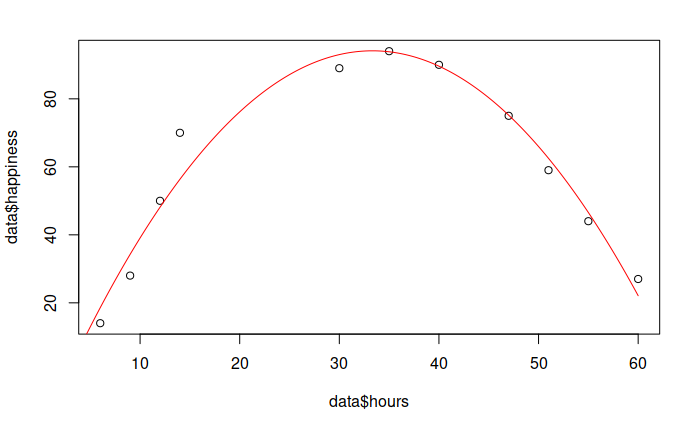

```r
hourValues <- seq(0, 60, 0.1)
happinessPredict <- predict(quadraticModel,data.frame(hours=hourValues, hours2=hourValues^2))

plot(data$hours, data$happiness)
lines(hourValues, happinessPredict, col='red')
```

Μπορούμε να προβλέψουμε τον βαθμό ευτυχίας με βάση συγκεκριμένες ώρες εργασίας:

```r
hours=c(10,20,30,60)
predict(quadraticModel,data.frame(hours=hours, hours2=hours^2))
```

```
       1        2        3        4
39.06998 76.15367 92.99744 22.08920
```